# Exploratory Data Analysis of Dating Platform: Veggie Mingle

Bret Wilde-Webster

17 February 2025

# 1. Introduction

Veggie Mingle is a dating platform for vegetarians, vegans, and other plant-based diet enthusiasts in the US. Individuals who share these diets often share common beliefs, mindsets, and lifestyles. Hence, the thinking goes, they might be interested in finding like-minded partners who share their same ethical, environmental, and health perspectives.

The challenge that Veggie Mingle faces, despite a dedicated user base and a very clear niche, is that match rates (whether or not any given individual does or does not find a match in a given time period) continue to remain low. The goal of this report is to conduct exploratory data analysis and develop machine learning models in order to identify which factors contribute to a successful match.

If users, no matter how much they may enjoy the platform, do not see successful results- they may begin to leave the platform. Understanding how and why people either do or do not match is crucial to the future success of Veggie Mingle.

### 1.1 Study and Data Summary

The data consists of 5000 records, split across 35 variables. 70% of the data is qualitative, representing lifestyle choices or demographic information. The remaining 30% is quantitative, representing more granular information, such as age, online activity, and profile completeness. Refer to Tables 2.0.1 and 2.0.2 for an overview of the data types and match outcomes.

The guiding question of this report is, “What user attributes contribute most significantly to a successful match on Veggie Mingle?”

The report seeks to answer this through evaluating six specific variables. Those factors are: favorite activity (1), alcohol consumption levels (2), income levels (3), travel preferences (4), music preferences (5), and how often one was active on the dating app (measured as “Online Activity” (6)).

Afterwards, we will present our most key considerations from the analysis. This includes revisiting the findings deemed most important, additional insights only available once the initial findings are available, and new questions for future analysis. Finally, we will put forward our actionable recommendations based on those conclusions.

### 1.2 Preliminary Conclusions:

1. There are two outcome variables, the most important one being “Matched,” with levels “Yes” or “No.” The second is “Total Matches” which is a numeric variable that measures the total matches for each user. Both metrics are measured within the first 30 days of a user joining Veggie Mingle.
   1. The median total matches is five, with a standard deviation of two. This means that if a user does successfully match, even once, on average, they will match four more times. Refer to Table 2.0.3 to see basic summary statistics on total matches.
   2. This means that the value of matching the very first time is disproportionately more effective and important in determining total matches than any other variable.
2. Relationships between Matched and other variables, if they exist, have very small effects on matching outcomes. Machine Learning models, as a result, struggled to accurately predict correct outcomes.

# 2. Exploratory Data Analysis

These factors were chosen specifically because they represent variability in lifestyle choices, which, given that the premise of Veggie Mingle is predicated upon similar lifestyle and diet choices- seem like an apt place to find important differences in match outcomes. The data set is skewed, with only 35% of users receiving at least one match.

The hypothesis in selecting these specific variables, is that there is a relationship between self-identified lifestyle preferences and matching.

## 2.1 Activity Preferences

Is there a relationship between activity preferences and receiving a match?

**Data**

“Favorite Activity” is a categorical variable consisting of four levels, Hiking, Yoga, Music, and Reading. Users identify which activity is their favorite among these four. This variable was combined with “Matched” to see if any activities had higher shares of matches than any other activities.

**Method**

Frequency distributions were computed to evaluate the two variables for a relationship. To visualize that distribution, a stacked bar chart was created displaying the ratio of favorite activities by match outcome.

**Analysis**

Table 2.1.1 shows that all activity preferences have very similar ratios of “Yes” to “No” for matching. Yoga has the highest proportion of successes. Figure_2.1.1, a stacked bar plot, shows that any difference in proportions is exceedingly small.

**Results**

There is not enough evidence to conclude that a relationship exists between favorite activity and receiving a match. At first glance, it might seem that there are significant differences in the number of matches for each activity. However, this difference is due to the unequal distribution of total selections—more people enjoy hiking than reading, for example. When we look at the proportion of each activity’s selections that result in a match, the differences become less significant. See Figure 2.1.1 for more details.

## 2.2 Alcohol Consumption

Is there a relationship between alcohol consumption and receiving a match?

**Data**

“alcohol_consumption” is a categorical variable consisting of three levels, Never, Regularly, and Socially. Users identify which type of alcohol consumption matches their own among these three. This variable was combined with “Matched” to see if any level of alcohol consumption had higher shares of matches than any other activities.

**Method**

Two frequency distributions were computed to evaluate the two variables for a relationship. The first created a cross tabulation of alcohol consumption levels on the entire data set, Table 2.2.1. The second shows the ratio of match outcomes by alcohol consumption levels, 2.2.2.

**Analysis**

Table 2.2.1 shows an extremely unequal distribution of alcohol consumption levels, with social drinkers accounting for just above 50% of all users. “Never” accounts for 39.5%, and “Regularly” accounts for 10%.

Table 2.2.2 shows a small range of differences among “Yes” match outcomes. Social drinkers are 5.2% more likely to receive a match than regular drinkers, and 2% more likely than those who never drink.

**Results**

The differences between the ratios within each category are small and might seem insignificant on their own. However, since social drinkers make up half of all users and are the most likely to receive a match compared to other alcohol consumption categories, they have a significant advantage. Half of the time a user is on Veggie Mingle, they will either be viewing the profile of a social drinker or be a social drinker themselves.

This overlap in interests, combined with the slightly higher odds of success for social drinkers, provides enough evidence to suggest a potential relationship between alcohol consumption and receiving a match.

## 2.3 Income Levels

Is there a relationship between income level and receiving a match?

**Data**

“income_level” is a categorical variable consisting of three levels, High, Middle, and Low. Users identify which income level matches their own among these three. This variable was combined with “Matched” to see if any income level contributes more to a successful match than any other level of income.

**Method**

Two frequency distributions and a summary table were computed to evaluate the two variables for a relationship. The first created a cross tabulation of income levels on the entire data set, Table 2.3.1. The second shows the ratio of match outcomes by income levels, Table 2.3.2.

Finally, Table 2.3.3 shows the average total matches across income levels.

**Analysis**

Observing Table 2.3.2, it would appear that proportionally, high income respondents see a minimal increase in match likelihood. High income minglers can expect to be matched 3.7% more than those identifying as “middle” income, and 1.4% more than “low” income.

Observing Table 2.3.1, high income users represent the smallest section of respondents, and there are far more total matches in “middle” income.

Looking at table 2.3.3, when isolating for just those respondents who had were matched; there is nearly no difference in average total matches between income levels.

**Results**

Despite representing almost half of the data set, users of middle income are the least likely to receive a match. High income users are more likely than any other group to receive a match, despite representing the smallest share of users. However, that increased likelihood is very slight. None the less, a difference does exist, and could imply a relationship between income levels and match likelihood.

## 2.4 Travel Preferences

Is there a relationship between travel preferences and receiving a match?

**Data**

“travel_preference” is a categorical variable consisting of four levels, Adventurous, Cultural, “Rarely Travel”, and Relaxing. Users identify which travel type they enjoy most among these four. This variable was combined with “Matched” to see if any travel preference contributes more to a successful match than any other.

**Method**

A summary table was created to evaluate the two variables for a relationship. Table 2.4.1. shows the ratio of successful matches by travel preferences, “MatchRatio”, the total count of users who prefer each travel type, “SelectionCount”, and the proportion of total users who selected each travel type, “SelectionRatio”.

**Analysis**

Table 2.4.1 shows that 37% of users who prefer adventurous travel received matches—3.5% higher than cultural travelers, 3.1% higher than those who rarely travel, and 2.6% higher than those who prefer relaxing vacations. Interestingly, only 10% of users reported rarely traveling, suggesting that Veggie Mingle attracts users who enjoy some form of travel. This is consistent with the platform’s focus on shared lifestyle traits.

**Results**

The proportion of successful matches for travel preferences other than Adventurous is within 1%, while Adventurous stands apart with a higher match rate. This suggests a potential relationship between travel preferences and match likelihood. Additionally, given that 90% of users enjoy some form of travel, users who also enjoy traveling are more likely to share a lifestyle in common with others, increasing their chances of a match.

## 2.5 Music Preferences

Is there a relationship between music preferences and receiving a match?

**Data**

“music_taste” is a categorical variable consisting of four levels, Classical, Jazz, Pop, and Rock. Users identify which type of music they enjoy most among these four. This variable was combined with “Matched” to see if any type of music taste contributes more to a successful match than any other.

**Method**

Two frequency distributions and a heat map were created to evaluate the two variables for a relationship.

The first frequency distribution shows the ratio of match outcomes by music taste, Table 2.5.1. The second shows a cross tabulation of music tastes across the entire data set, Table 2.5.2.

Finally, Figure 2.5.1 shows the shift in match likelihood by music taste, using a heatmap. A lighter green represents a higher number, and a darker shade of green represents a lower number.

**Analysis**

Looking to Table 2.5.1., nearly 70% of all users who enjoy pop music were unsuccessful in receiving a match, as opposed to those who enjoy classical music, of which 42% were successful in receiving a match

Users who enjoy classical music are 11.9% more likely to receive a match than those who enjoy pop music, 7.6% more likely than those who enjoy jazz, and 7.4% more likely than those who enjoy rock.

Referring to Table 2.5.2., more users prefer pop music than any other kind of music, while jazz has the lowest share of users. Rock and classical music are roughly tied.

**Results**

There is a clear and obvious preference among users for individuals with a taste for classical music. Users who identify classical music as their favorite see large and noticeable increase in positive match outcomes. Conversely, those with a taste for pop music are overwhelmingly unlikely to receive a match.

Referring again to the heat map, there is definitively enough evidence to conclude that a relationship exists between music taste and match likelihood.

## 2.6 Online Activity

Is there a relationship between different levels of online activity and receiving a match?

**Data**

“online_activity” is a numeric variable consisting of a scale from 1-10. It measures the hours the user spends online daily. This variable was combined with “Matched” to see if any type of music taste contributes more to a successful match than any other.

**Method**

Two frequency distributions and a violin plot were created to evaluate the two variables for a relationship.

The first frequency distribution shows the ratio of match outcomes by level of online activity, Table 2.6.1. The second shows a cross tabulation of online activity levels across the entire data set, Table 2.6.2.

Figure 2.6.1 shows the distribution of matches across “Yes” and “No” match outcomes across online activity.

**Analysis**

Looking at Table 2.6.1., the proportion of “Yes” responses across activity levels one through five remains steady, between 31% and 35%. However, at activity levels six and beyond, the likelihood of receiving a match increases significantly, with 38% to 42% of users at these levels receiving a match.

Table 2.6.2. shows that the data is skewed, with 74.9% of users falling within activity levels 1 to 5. Despite this skewness, the increased match likelihood at higher activity levels (6 and beyond) cannot be attributed to the distribution of users. Since the majority of users are concentrated at lower activity levels, the higher match likelihood at activity levels 6 and beyond is not simply a byproduct of skewness.

Figure 2.6.1., the violin plot, further illustrates this, with clear peaks observed between online activity levels 3 and 5. While the “No” plot shows sharper peaks, Table 2.6.3. reveals that both matched and unmatched individuals share the same average level of online activity.

**Results**

Based on the analysis, there is enough evidence to establish a relationship between higher online activity and positive match outcomes. While the distribution of online activity is skewed with the majority of users concentrated at lower activity levels, the significant increase in match likelihood at activity levels 6 and above indicates that users with higher online activity are more likely to receive a match.

# 3. ML Model Building Exercise

[output not shown]

## 3.0 Linear Regression

### Model Performance

R-squared measures how well the model explains how much of the change in the outcome variable (total matches) is explained by the change in the variables within the linear regression model. It ranges from 0 to 1, where 1 means the model perfectly predicts the outcomes, and 0 means it predicts nothing better than guessing the average.

Here, this models R² value is **0.02375** or 2.4%, meaning that only 2.4% of the change in our outcome is explained by the change in our model. Most of the variation in total matches remains unexplained.

RMSE measures the average difference between the model’s predictions and the actual data. Smaller values indicate a better fit. In this case, the model’s RMSE is **2.772**. So, on average, the model’s predictions for total matches are off by about 2.77 matches. Given the smaller scale, this is a relatively large margin of error.

## 3.3 Random Forest (Best Model)

### Model Performance

A **random forest** model consists of many different decision trees, which are like flowcharts used to determine what variables have the largest effect on the outcome. Each tree is trained on a different subset of data, and their answers are combined through a majority vote. This helps make the decision more accurate and reliable by considering different viewpoints and avoiding overfitting to any one set of details.

By way of explanation, we can observe the confusion matrix (Table 3.3.2). The confusion matrix reveals that the model misidentifies the vast majority of true positive values as false, but correctly identifies nearly all true negatives!

In other words, essentially, the model is shy. It is extremely cautious of predicting positive values, and over assigns its guesses to the “No” for predicted match values. Actually, almost all of its predictions were of the “No” value, which accounts for why it labeled all the true negatives correctly. This is likely due to the skewed nature of the data set, where more than 65% of the users did not get a match.

### Model and Variable Importance Explanation

The top three variables according to the plot are profile completeness, age, and account duration.

### Expected error on the model for future data

The model has extraordinarily high accuracy on negative values only. This indicates that if the model can be convinced to take more positive guesses, it may be far more accurate than it currently appears. But, until that modification is made, I would not recommend this model for deployment. It is currently exceedingly inaccurate, and given that it did not test well, it likely will not fare well on future data either.

# 4. Recommendations

### 1.) App Engagement

The exploratory data analysis shows that increased online activity is directly correlated with match likelihood (Table 2.6.1). The random forest variable importance plot (Figure 3.3.1) highly ranks profile completeness and account duraction as predictors for match success.

There should be a renewed focus on keeping Veggie Mingle users engaged and active on the app. This could be accomplished through more active users being shown more often to more active users, or disincentive incomplete profiles in the suggested profiles algorithm. There could also be incentives provided. If Veggie Mingle has paid “super likes” or other such resources normally paid for, perhaps upon a user fully completing their profile, they might receive one such paid resource for free.

Users are more likely to be satisfied on Veggie Mingle if, being an active user, they match with another active user. This could lead to more immediate conversations or faster outcomes. There is also the inherent assumption that a more active user is a more invested user, and therefore, when seeing another profile which has a higher online activity- is seeing another user more invested in successful matches.

### 2.) Emphasize Shared Lifestyle Traits

Repeatedly, in the exploratory data analysis and in the VIP plots for linear regression (Figure 3.0.2) and random forest (Figure 3.3.1), it was shown that various lifestyle selections led to increased match likelihood among Veggie Mingle users.

As a result, it might be wise to allow users to select, either hidden or publicly, values that they are “seeking.” These would not be mere filters, but rather would highlight shared values or lifestyle badges/identifiers on user profiles. It may also result in the algorithm which suggests user profiles to users pushing some profiles over others. These curated profiles would likely see higher positive match likelihoods, as we can see from the exploratory data analysis.

These changes, if successful, would lead to more matches. More matches would lead to higher user engagement, and therefore greater user satisfaction. This in turn would boost statistics for user success metrics, which could be leveraged for marketing and advertising.

### 3.) Allow for Greater Choice

Some features, such as travel preferences, favorite activity, and music taste, allow for a single selection. They also only contain a list of predetermined levels, usually three or four different categories. In reality, users are likely more diverse than these categories. Allowing for more choices would allow users to be more specific, and in turn, see more specifically what they want in dating partners.

The conclusions that the exploratory data analysis and ML modeling lead to repeatedly show that overlapping interests present higher likelihoods for positive match outcomes. Allowing users more choice in how they present themselves to other users allows for narrower overlap between other users with those specific tastes– and therefore much better match likelihoods in those groups.

The upsides here are the same as before, higher engagement, greater user satisfaction, and a better bottom line for Veggie Mingle.

# 5. Conclusion

This project sought to identify the key factors driving successful matches on Veggie Mingle and to provide actionable insights for improving the platform’s performance.The initial hypothesis proposed by the exploratory data analysis was that there is a relationship between self-identified lifestyle preferences and match likelihood. This held true.

The analysis revealed that higher online activity and shared lifestyle traits are associated with increased match likelihood, while some lifestyle preferences, such as favorite music, have notable impacts on match outcomes.

However, the skewed data set and small effect sizes posed challenges for predictive modeling, resulting in models with limited discriminatory power. Despite these limitations, the findings underscore the importance of user engagement, profile completeness, and shared values in increasing match likelihood.

The recommendations outlined—such as incentives to complete profiles, highlighting shared traits, and expanding user options—are designed to address these findings. While the current analysis is a strong starting point, future work should focus on gathering additional data, refining feature engineering, and testing the impact of suggested changes on user outcomes.

By implementing these strategies, Veggie Mingle can enhance user satisfaction, improve match rates, and strengthen its position as the go-to dating platform for users with plant-based diets. .

# 6. Appendices

## Data Prep

Loading relevant libraries and preparing data.

```r
## Add R libraries here
library(tidyverse)
library(knitr)
library(tidymodels)
library(janitor)
library(discrim)
library(vip)
library(rpart.plot)
library(ranger)
library(skimr)
library(RColorBrewer)

# Load data
VeggieData <- read_csv("C:/Users/BretC/Desktop/School Work/GMU Fall 2024/MIS 431 - Data Mining for Business Applications/COURSE COMPLETED - RESOURCES/PROJECTS/FinalProject_Modeling_and_EDA.zp/Datasets/Veggiemingle.csv") |>
  select(-1) # Remove duplicate primary key

# Get the data looking right
VeggieData <- VeggieData |>
  clean_names() # Names have been transformed


levels(VeggieData$matched) # Returns Null. Its an outcome variable, so it needs levels to be classified.

# Reformat the outcome variable as a factor, so that it can be understood by the models.
VeggieData <- VeggieData |>
   mutate(matched = factor(matched,
                           levels = c('Yes', 'No')))
```

## 6.1 Exploratory Data Analysis

Getting familiar with the data set.

```r
Table_2.0.1 <- VeggieData |>
  sapply(class) |>
  tabyl() |>
  adorn_pct_formatting()
# Mostly qualititative, 70% of the data is categorical, with the remaining 30% being numeric.

# Assess for skewness
Table_2.0.2 <- VeggieData |>
  tabyl(matched) |>
  adorn_pct_formatting() # 1750, or 35% of the total data pool receive  matches.


# What about just the group of individuals who received matches?
VeggieWinners <- VeggieData |>
  filter(matched == "Yes")

# Summary statistics for matched users
WinnerTable <-  VeggieWinners |>
  summarize(Mean = mean(total_matches),
            SD = sd(total_matches),
            Median = median(total_matches),
            Max = max(total_matches),
            Min = min(total_matches),
            '1st_Qu' = quantile(total_matches, 0.25),
            '3rd_Qu' = quantile(total_matches, 0.75))


Table_2.0.3 <- round(WinnerTable, 2)
```

Table 2.0.1: Frequency Table of Data Types

| sapply(VeggieData, class) | n | percent |
| --- | --- | --- |
| character | 23 | 67.6% |
| factor | 1 | 2.9% |
| numeric | 10 | 29.4% |

Table 2.0.2: Frequency Table of Successful Matches

| matched | n | percent |
| --- | --- | --- |
| Yes | 1750 | 35.0% |
| No | 3250 | 65.0% |

Table 2.0.3: Summary Table of Total Matches

| Mean | SD | Median | Max | Min | 1st_Qu | 3rd_Qu |
| --- | --- | --- | --- | --- | --- | --- |
| 5.14 | 2.25 | 5 | 14 | 0 | 4 | 7 |

### Favorite Activity

Table 2.1.1: Frequency Table of Succesful Matches by Favorite Activity

| favorite_activity | Yes | No |
| --- | --- | --- |
| Hiking | 35.4% (521) | 64.6% (951) |
| Music | 34.0% (345) | 66.0% (670) |
| Reading | 33.4% (418) | 66.6% (835) |
| Yoga | 37.0% (466) | 63.0% (794) |

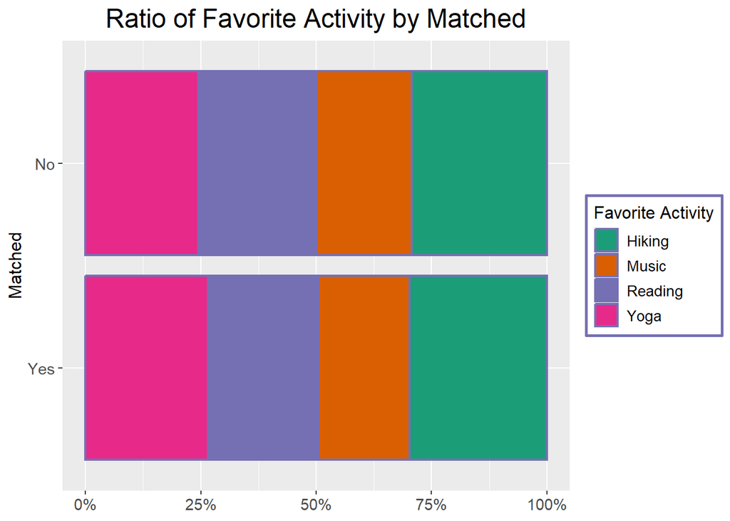

Figure 2.1.1: Grouped Barplot of Favorite Activity by Matched

```r
Table_2.1.1 <- VeggieData |>
  tabyl(favorite_activity, matched) |>
  adorn_percentages() |>
  adorn_pct_formatting() |>
  adorn_ns()


Figure_2.1.1 <- VeggieData |>
  ggplot(aes(y = matched, fill = favorite_activity)) +
  geom_bar(position = 'fill',  color = "#7570b3", size = 0.75) +
  scale_fill_brewer(palette = "Dark2") +
  labs(title = "Ratio of Favorite Activity by Matched", x = NULL , y = "Matched", fill = "Favorite Activity") +
  scale_x_continuous(labels = label_percent()) +
  theme(
    plot.title = element_text(hjust = 0.5, size = 18),
axis.title.y = element_text(size = 12),
axis.title.x = element_text(size = 12),
axis.text.y = element_text(size = 11),
axis.text.x = element_text(size = 11),
legend.text = element_text(size = 10.5),
legend.title = element_text(size = 12),
legend.background = element_rect(fill = "white", color = "#7570b3", size = 1))
```

### Alcohol Consumption

```r
# See the split of alcohol consumption levels on the entire data set
Table_2.2.1 <- VeggieData |>
  tabyl(alcohol_consumption) |>
  adorn_pct_formatting()

# See the ratio of match outcomes by alcohol consumption
Table_2.2.2 <- VeggieData |>
  tabyl(alcohol_consumption, matched) |>
  adorn_percentages() |>
  adorn_pct_formatting() |>
  adorn_ns()
```

Table 2.2.1: Frequency Table of Alcohol Consumption

| alcohol_consumption | n | percent |
| --- | --- | --- |
| Never | 1976 | 39.5% |
| Regularly | 502 | 10.0% |
| Socially | 2522 | 50.4% |

Table 2.2.2: Frequency Table of Alcohol Consumption and Successful Matches

| alcohol_consumption | Yes | No |
| --- | --- | --- |
| Never | 34.3% (678) | 65.7% (1,298) |
| Regularly | 31.1% (156) | 68.9% (346) |
| Socially | 36.3% (916) | 63.7% (1,606) |

### Income Level

```r
Table_2.3.1 <- VeggieData |>
  tabyl(income_level)

Table_2.3.2 <- VeggieData |>
  tabyl(income_level, matched) |>
  adorn_percentages() |>
  adorn_pct_formatting() |>
  adorn_ns()

Table_2.3.3 <- VeggieWinners |>
  group_by(income_level) |>
  summarise(AverageMatches = round(mean(total_matches), 2))
```

Table 2.3.1: Frequency Table of Income Levels

| income_level | n | percent |
| --- | --- | --- |
| High | 1012 | 0.2024 |
| Low | 1503 | 0.3006 |
| Middle | 2485 | 0.4970 |

Table 2.3.2: Frequency Table of Income Levels and Matched

| income_level | Yes | No |
| --- | --- | --- |
| High | 37.3% (377) | 62.7% (635) |
| Low | 35.9% (539) | 64.1% (964) |
| Middle | 33.6% (834) | 66.4% (1,651) |

Table 2.3.3: Summary Table of Average Matches by Income Level

| income_level | AverageMatches |
| --- | --- |
| High | 5.23 |
| Low | 5.11 |
| Middle | 5.11 |

### Travel Preferences

```r
Table_2.4.1 <- VeggieData |>
  group_by(travel_preference) |>
  summarize(MatchRatio = round(mean(matched == "Yes")* 100, 2),
            SelectionCount = n()) |>
  mutate(SelectionRatio = round(SelectionCount / sum(SelectionCount) * 100, 2))
```

Table 2.4.1: Summary Table of Travel Preferences

| travel_preference | MatchRatio | SelectionCount | SelectionRatio |
| --- | --- | --- | --- |
| Adventurous | 37.03 | 1747 | 34.94 |
| Cultural | 33.51 | 1504 | 30.08 |
| Rarely Travel | 33.94 | 545 | 10.90 |
| Relaxing | 34.39 | 1204 | 24.08 |

### Music Tastes

Table 2.5.1: Frequency Table of Music Tastes by Matched

| music_taste | Yes | No |
| --- | --- | --- |
| Classical | 42.0% | 58.0% |
| Jazz | 34.4% | 65.6% |
| Pop | 30.1% | 69.9% |
| Rock | 34.6% | 65.4% |

Table 2.5.2: Frequency Table of Total Music Tastes

| matched | Classical | Jazz | Pop | Rock |
| --- | --- | --- | --- | --- |
| Yes | 516 | 345 | 454 | 435 |
| No | 714 | 658 | 1054 | 824 |
| Total | 1230 | 1003 | 1508 | 1259 |

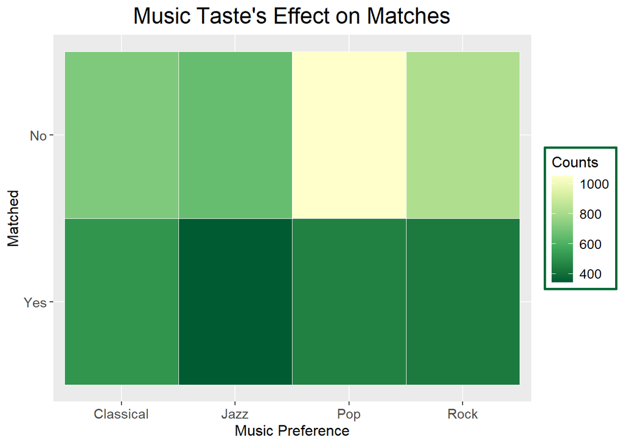

Figure 2.5.1: Heatmap of Music Tastes by Matched

```r
Table_2.5.1 <- VeggieData |>
  tabyl(music_taste, matched) |>
  adorn_percentages() |>
  adorn_pct_formatting()

Table_2.5.2 <- VeggieData |>
  tabyl(matched, music_taste) |>
  adorn_totals()

MusicHeatMap <- VeggieData |> # Creating a counts table for a heatmap
  group_by(music_taste, matched) |>
  summarize(count = n()) |>
  ungroup()

Figure_2.5.1 <- MusicHeatMap |>
  ggplot(aes(x = music_taste, y = matched, fill = count)) +
  geom_tile(color = "white") +
  scale_fill_distiller(palette = "YlGn") +
  labs(title = "Music Taste's Effect on Matches", x = "Music Preference", y = "Matched", fill = "Counts") +
  theme(
    plot.title = element_text(hjust = 0.5, size = 18),
axis.title.y = element_text(size = 12),
axis.title.x = element_text(size = 12),
axis.text.y = element_text(size = 11),
axis.text.x = element_text(size = 11),
legend.text = element_text(size = 10.5),
legend.title = element_text(size = 12),
legend.background = element_rect(fill = "white", color = "#006837", size = 1))
```

### Online Activity

Table 2.6.1: Frequency Table of Match Likelihood by Online Activity Level

| online_activity | Yes | No |
| --- | --- | --- |
| 1 | 33.2% | 66.8% |
| 2 | 32.4% | 67.6% |
| 3 | 35.1% | 64.9% |
| 4 | 34.1% | 65.9% |
| 5 | 31.7% | 68.3% |
| 6 | 40.1% | 59.9% |
| 7 | 39.2% | 60.8% |
| 8 | 37.7% | 62.3% |
| 9 | 42.2% | 57.8% |
| 10 | 40.4% | 59.6% |

Table 2.6.2: Frequency Table of Total Online Activity Levels

| online_activity | n | percent |
| --- | --- | --- |
| 1 | 253 | 5.1% |
| 2 | 500 | 10.0% |
| 3 | 1045 | 20.9% |
| 4 | 929 | 18.6% |
| 5 | 1017 | 20.3% |
| 6 | 516 | 10.3% |
| 7 | 260 | 5.2% |
| 8 | 260 | 5.2% |
| 9 | 116 | 2.3% |
| 10 | 104 | 2.1% |

Table 2.6.3: Average Online Activity level by Matched

| matched | MedianOnlineActivity |
| --- | --- |
| Yes | 4 |
| No | 4 |

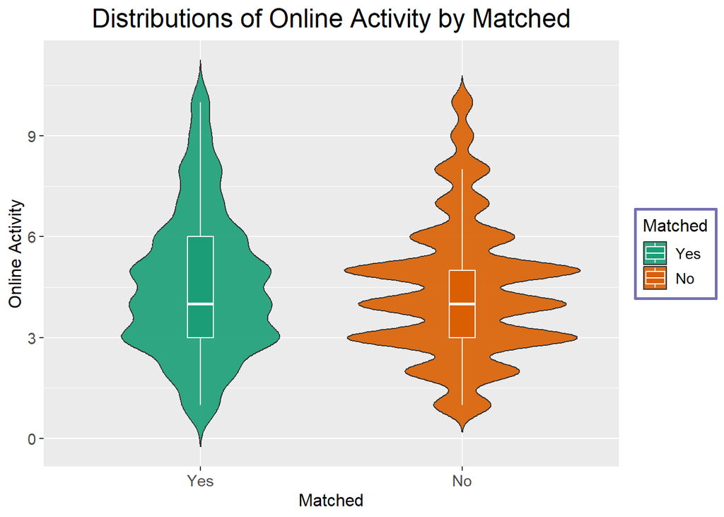

Figure 2.6.1: Violin Plot of Online Activity Levels by Matched

```r
Table_2.6.1 <- VeggieData |>
  tabyl(online_activity, matched) |>
  adorn_percentages() |>
  adorn_pct_formatting()

Table_2.6.2 <- VeggieData |>
  tabyl(online_activity) |>
  adorn_pct_formatting()

Table_2.6.3 <- VeggieData |>
  group_by(matched) |>
  summarize(MedianOnlineActivity = round(median(online_activity), 2))


Figure_2.6.1 <- VeggieData |>
  ggplot(aes(x = matched, y = online_activity, fill = matched)) +
  geom_violin(trim = FALSE, alpha = 0.9) +
  geom_boxplot(color = "white", width = 0.1, outlier.shape = NA) +  # Match boxplot colors to violins
  scale_fill_brewer(palette = "Dark2") +
  labs(
    title = "Distributions of Online Activity by Matched",
    x = "Matched",
    y = "Online Activity",
    fill = "Matched",
    color = "Matched") +
  theme(
    plot.title = element_text(hjust = 0.5, size = 18),
    axis.title.y = element_text(size = 12),
    axis.title.x = element_text(size = 12),
    axis.text.y = element_text(size = 11),
    axis.text.x = element_text(size = 11),
    legend.text = element_text(size = 10.5),
    legend.title = element_text(size = 12),
    legend.background = element_rect(fill = "white", color = "#7570b3", size = 1))
```

## 6.2 Machine Learning Models

We split the data, but, because there are two outcome variables, we have to remove the categorical variable from the Linear Regression model. This means we’ll need to do this splitting a second time, with cross validation included, for the classification models.

```r
set.seed(1443385)

# Split it.
MingleSplit <- VeggieData |>
  initial_split(prop = 0.75, strata = matched)

# Training
MingleTraining <- MingleSplit |>
  training()

# Testing
MingleTesting <- MingleSplit |>
  testing()

Minglefolds <- vfold_cv(VeggieData, v = 5)
```

**We need to create two different recipes, one for regression models and another for classification models.**

```r
# Need two recipes, one for the linear regression model with "Total Matches"
RegressionRecipe <- recipe(total_matches ~ ., data = MingleTraining) |>
                   step_rm(matched, user_id) |> # Identifier variable may lead to overfitting, and is irrelevant to predictions.
                   step_YeoJohnson(all_numeric(), -all_outcomes()) |>
                   step_normalize(all_numeric(), -all_outcomes()) |>
                   step_dummy(all_nominal(), - all_outcomes())

# And one for classification models with "Matched."
ClassificationRecipe <- recipe(matched ~ ., data = MingleTraining) |>
                   step_rm(total_matches, user_id) |> # Identifier variable may lead to overfitting, and is irrelevant to predictions.
                   step_YeoJohnson(all_numeric(), -all_outcomes()) |>
                   step_normalize(all_numeric(), -all_outcomes()) |>
                   step_dummy(all_nominal(), - all_outcomes())
```

Check to see if the transformations worked as intended

```r
# Regression Transformations
Regression_Training_Baked <- RegressionRecipe |>
  prep() |>
  bake(new_data = MingleTraining)

# View results
Regression_Training_Baked

# Classification Transformations
Classification_Training_Baked <- ClassificationRecipe |>
  prep() |>
  bake(new_data = MingleTraining)

# View results
Classification_Training_Baked
```

### Linear Regression

#### Create Model

```r
Mingle_LM <- linear_reg() |>
            set_engine('lm') |>
            set_mode('regression')
```

Add a workflow to it

```r
LM_WF <- workflow() |>
  add_model(Mingle_LM) |>
  add_recipe(RegressionRecipe)
```

Okay now lets deploy the model

```r
LM_Fit_Auto <- LM_WF |>
  last_fit(split = MingleSplit)
```

How does the model do?

```r
# See the performance metrics
Table_3.0.1 <-  LM_Fit_Auto |>
  collect_metrics()

# See the predictions
LM_Results <- LM_Fit_Auto |>
  collect_predictions()
```

Table_3.0.1: Linear Model Metrics

| .metric | .estimator | .estimate | .config |
| --- | --- | --- | --- |
| rmse | standard | 2.8289144 | Preprocessor1_Model1 |
| rsq | standard | 0.0019012 | Preprocessor1_Model1 |

```r
#  manually fit the data
LM_Fit_Manual <- Mingle_LM |>
fit(total_matches ~ ., data = Regression_Training_Baked)
```

```
## Table 3.0.2: Linear Model Summary:
```

```
##
## Call:
## stats::lm(formula = total_matches ~ ., data = data)
##
## Residuals:
##    Min     1Q Median     3Q    Max
## -3.276 -1.877 -1.436  1.828 12.293
##
## Coefficients:
##                                  Estimate Std. Error t value Pr(>|t|)
## (Intercept)                      2.621206   0.345436   7.588 4.09e-14 ***
## age                             -0.037273   0.047994  -0.777  0.43744
## diet_duration_years             -0.066617   0.047810  -1.393  0.16359
## cooking_skill                   -0.005893   0.046657  -0.126  0.89950
## relationship_history            -0.100032   0.045964  -2.176  0.02960 *
## reading_habits                   0.075297   0.045692   1.648  0.09945 .
## online_activity                  0.098028   0.045643   2.148  0.03180 *
## account_duration                -0.008865   0.045722  -0.194  0.84628
## profile_completeness             0.058127   0.045672   1.273  0.20320
## gender_Male                     -0.007754   0.091515  -0.085  0.93248
## location_Dallas                 -0.272194   0.204515  -1.331  0.18330
## location_Houston                -0.240389   0.200065  -1.202  0.22961
## location_Los.Angeles            -0.180916   0.190385  -0.950  0.34204
## location_New.York               -0.302279   0.182456  -1.657  0.09766 .
## location_Philadelphia           -0.136624   0.213226  -0.641  0.52173
## location_Phoenix                -0.082662   0.197790  -0.418  0.67602
## location_San.Antonio            -0.155651   0.217702  -0.715  0.47467
## location_San.Diego               0.058388   0.225385   0.259  0.79560
## location_San.Jose               -0.160413   0.213023  -0.753  0.45148
## diet_type_Raw.Vegan             -0.186930   0.181884  -1.028  0.30414
## diet_type_Vegan                 -0.085343   0.132964  -0.642  0.52101
## diet_type_Vegetarian             0.092423   0.124551   0.742  0.45811
## reason_for_diet_Ethical          0.191912   0.141871   1.353  0.17623
## reason_for_diet_Health           0.139645   0.138541   1.008  0.31353
## reason_for_diet_Religious        0.080197   0.212387   0.378  0.70575
## dietary_transition_In.Phases     0.098714   0.119827   0.824  0.41010
## dietary_transition_Overnight    -0.114581   0.121364  -0.944  0.34518
## favorite_cuisine_Indian         -0.060843   0.123744  -0.492  0.62297
## favorite_cuisine_Mediterranean  -0.050183   0.128501  -0.391  0.69617
## favorite_cuisine_Western        -0.104386   0.137133  -0.761  0.44659
```

[output cut: 28 more lines]

```
## movie_preference_Romance        -0.157061   0.123102  -1.276  0.20209
## app_usage_frequency_Weekly       0.037572   0.099411   0.378  0.70549
## event_attendance_Often           0.054918   0.131996   0.416  0.67739
## event_attendance_Rarely          0.077770   0.105484   0.737  0.46100
## referral_source_Online.Ad       -0.098281   0.110925  -0.886  0.37567
## referral_source_Social.Media    -0.064608   0.110504  -0.585  0.55880
## response_rate_Often             -0.161452   0.105531  -1.530  0.12613
## response_rate_Rarely             0.045623   0.129658   0.352  0.72495
## safety_concerns_Yes              0.020950   0.153777   0.136  0.89164
## ---
## Signif. codes:  0 '***' 0.001 '**' 0.01 '*' 0.05 '.' 0.1 ' ' 1
##
## Residual standard error: 2.772 on 3682 degrees of freedom
## Multiple R-squared:  0.02375,    Adjusted R-squared:  0.006255
## F-statistic: 1.357 on 66 and 3682 DF,  p-value: 0.02975
```

**Fit the model to the baked training data**

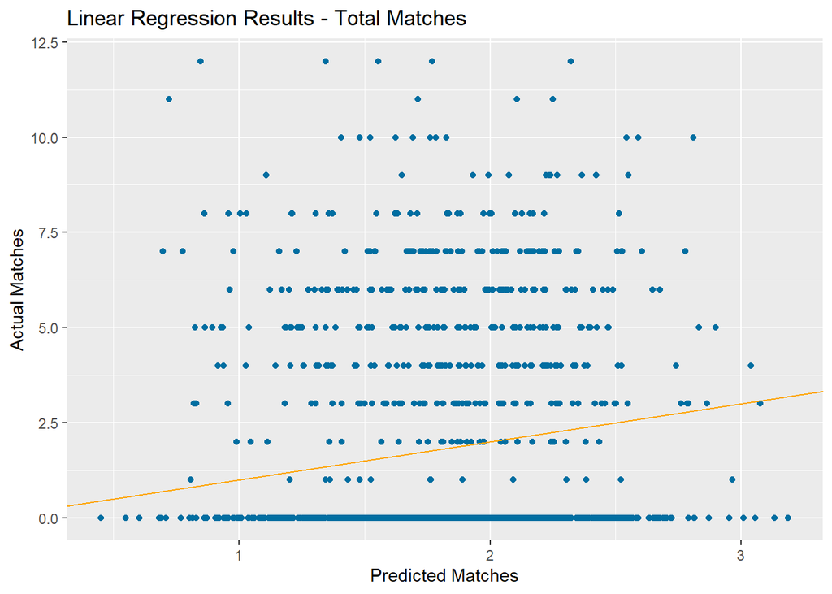

Figure 3.0.1: Line Plot of Regression Predictions

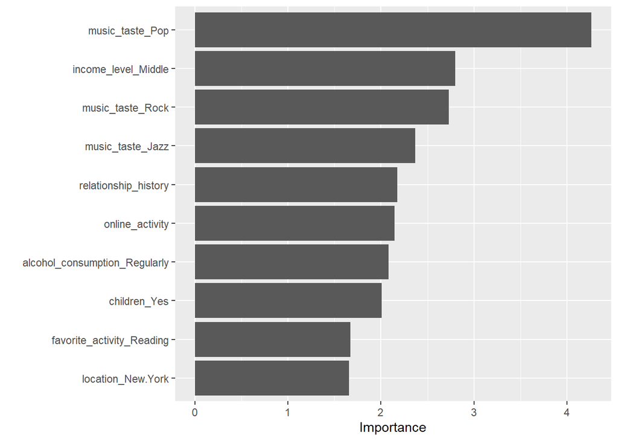

Figure 3.0.2: Linear Regression Variable Importance Plot

```r
Figure_3.0.2 <- vip(LM_Fit_Manual)
```

### Logistic Regression

#### Create Model

```r
Mingle_LR <- logistic_reg() |>
            set_engine('glm') |>
            set_mode('classification')
```

Deploy the model

```r
Logistic_fit <- LR_WF |>
  last_fit(split = MingleSplit)
```

#### Performance Metrics

Specific Metrics

```r
# ROC AUC score
Table_3.1.1 <- Logistic_Results |>
  roc_auc(truth = matched, .pred_Yes)

# Confusion Matrix
Logistic_Results |>
  conf_mat(truth = matched, .pred_class)

# F1 Measure
Table_3.1.3 <- Logistic_Results |>
  f_meas(truth = matched, .pred_class)
```

Table 3.1.1: : Logistic Regression ROCAUC Score

| .metric | .estimator | .estimate |
| --- | --- | --- |
| roc_auc | binary | 0.5344038 |

```
## Table 3.1.2: Logistic Confusion Matrix:
```

```
##           Truth
## Prediction Yes  No
##        Yes  20  25
##        No  418 788
```

Table 3.1.3: Logistic Regression F1 Score

| .metric | .estimator | .estimate |
| --- | --- | --- |
| f_meas | binary | 0.0828157 |

#### ROC Curve

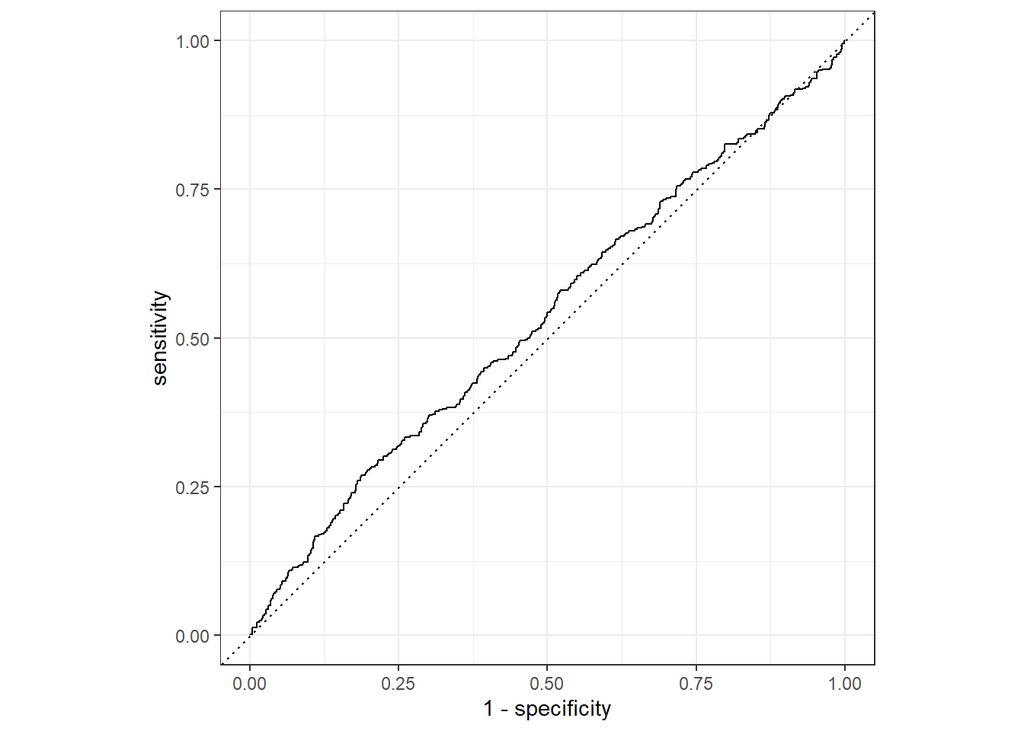

Figure 3.1.1: Logistic Regression ROC Curve

```r
#ROC Curve
Figure_3.1.1 <- Logistic_Results |>
roc_curve(truth = matched, .pred_Yes) |>
autoplot() # Not good
```

### Quadratic Discriminant Analysis Modeling

#### Create Model

```r
# Load relevant libraries
library(klaR)
library(MASS)


Mingle_QDA <- discrim_regularized(frac_common_cov = 0) %>%
             set_engine('klaR') %>%
             set_mode('classification')
```

Add workflow

```r
QDA_WF <- workflow() |>
  add_model(Mingle_QDA) |>
  add_recipe(ClassificationRecipe)
```

deploy the model

```r
Quadratic_fit <- QDA_WF |>
  last_fit(split = MingleSplit)
```

#### Performance Metrics

Specific Metrics

```r
# ROC AUC score
Table_3.2.1 <- Quadratic_Results |>
  roc_auc(truth = matched, .pred_Yes)

# Confusion Matrix
Quadratic_Results |>
  conf_mat(truth = matched, .pred_class)

# F1 Measure
Table_3.2.3 <- Quadratic_Results |>
  f_meas(truth = matched, .pred_class)
```

Table 3.2.1: : QDA ROCAUC Score

| .metric | .estimator | .estimate |
| --- | --- | --- |
| roc_auc | binary | 0.5424326 |

```
## Table 3.2.2: QDA Confusion Matrix:
```

```
##           Truth
## Prediction Yes  No
##        Yes  68  97
##        No  370 716
```

Table 3.2.3: QDA F1 Score

| .metric | .estimator | .estimate |
| --- | --- | --- |
| f_meas | binary | 0.225539 |

#### ROC Curve

plot the curve to check what the metrics show us.

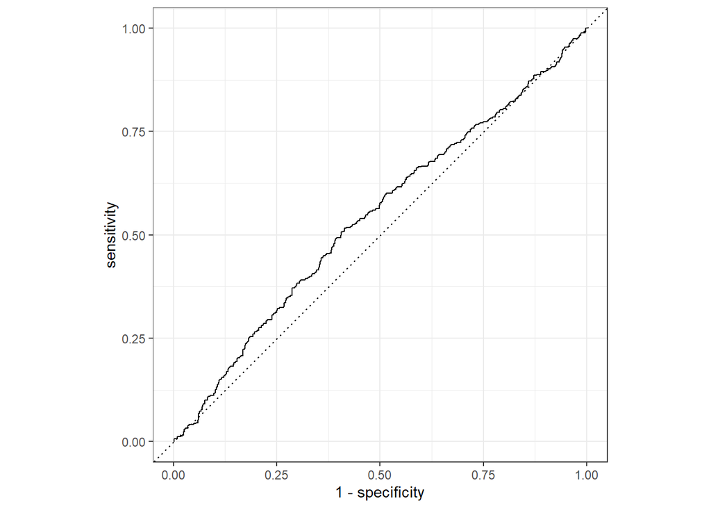

```r
#ROC Curve
Figure_3.2.1 <- Quadratic_Results |>
roc_curve(truth = matched, .pred_Yes) |>
autoplot()
```

### Random Forest

#### Create Model

```r
Mingle_Forest <-  rand_forest(mtry = tune(),
                              trees = tune(),
                              min_n = tune()) |>
  set_engine('ranger', importance = "impurity") |>
  set_mode('classification')
```

Add a workflow to it

```r
Forest_WF<- workflow() |>
  add_model(Mingle_Forest) |>
  add_recipe(ClassificationRecipe)
```

#### Hyperparameter Tuning with tune_grid()

```r
set.seed(1443385)

# Create a random grid for tuning
rf_grid <- grid_random(mtry() |>
                         range_set(c(5, 30)), # Dataframe has 35 columns, chopped five off either end to get a range mostly in the middle and away from the ends
                       trees(),
                       min_n(),
                       size = 10)

# Tuning Hyperparamters using resampling
rf_tuning <- Forest_WF |>
             tune_grid(resamples = Minglefolds,
                       grid = rf_grid)

# show the top 5 best models based on ROCAUC
rf_tuning |>
  show_best(metric = 'roc_auc')
```

```
## # A tibble: 5 × 9
##    mtry trees min_n .metric .estimator  mean     n std_err .config
##   <int> <int> <int> <chr>   <chr>      <dbl> <int>   <dbl> <chr>
## 1    20   887    17 roc_auc binary     0.582     5 0.00926 Preprocessor1_Model02
## 2    26    90    31 roc_auc binary     0.578     5 0.00920 Preprocessor1_Model05
## 3    24   309    23 roc_auc binary     0.577     5 0.00947 Preprocessor1_Model04
## 4    13  1553    13 roc_auc binary     0.576     5 0.0100  Preprocessor1_Model03
## 5    16   148    30 roc_auc binary     0.574     5 0.0102  Preprocessor1_Model09
```

```r
# Now choose the best among those

Best_RF <- rf_tuning %>%
           select_best(metric = 'roc_auc')
```

#### Finalize Workflow

Now that we have our most optimal model, lets add it to our workflow

```r
Final_Forest_WF <- Forest_WF |>
  finalize_workflow(Best_RF)
```

#### Evaluate variable importance with a VIP

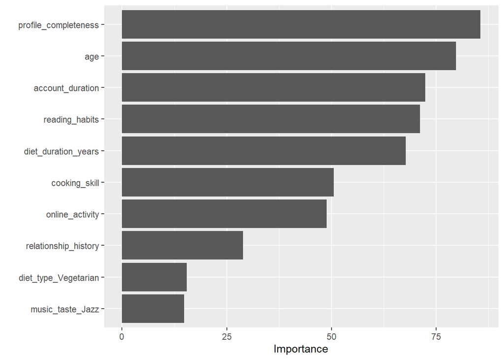

```r
# Fit the workflow to the training data
Forest_Workflow_Fit <-  Final_Forest_WF |>
  fit(data = MingleTraining)

# Extract the trained model from the workflow fit.
ForestFit <- Forest_Workflow_Fit |>
  extract_fit_parsnip()

# Evaluate variable importance
Figure_3.3.1 <- vip(ForestFit)
```

#### Train and Evaluate

```r
# Train and test
MingleForestLastFit <- Final_Forest_WF |>
  last_fit(MingleSplit)
```

Evaluate performance metrics

Specific Metrics

```r
# ROC AUC score
Table_3.3.1 <- Forest_Results |>
  roc_auc(truth = matched, .pred_Yes)

# Confusion Matrix
Forest_Results |>
  conf_mat(truth = matched, .pred_class)

# F1 Measure
Table_3.3.3 <- Forest_Results |>
  f_meas(truth = matched, .pred_class)
```

Table 3.3.1: : Random Forest ROCAUC Score

| .metric | .estimator | .estimate |
| --- | --- | --- |
| roc_auc | binary | 0.5828012 |

```
## Table 3.3.2: Random Forest Confusion Matrix:
```

```
##           Truth
## Prediction Yes  No
##        Yes  37   2
##        No  401 811
```

Table 3.3.3: Random Forest F1 Score

| .metric | .estimator | .estimate |
| --- | --- | --- |
| f_meas | binary | 0.1551363 |

Plot the ROC curve of the model

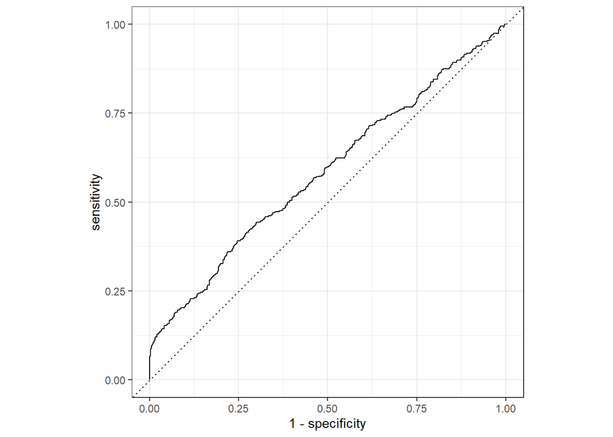

Figure 3.3.2: Random Forest ROC Curve

```r
#ROC Curve
Figure_3.3.2 <- Forest_Results |>
roc_curve(truth = matched, .pred_Yes) |>
autoplot() # Better, but still not great.
```

— End of the Project —